# simulation

renyan

2022/4/11

# 模拟数据生成

```r
rm(list = ls(all = TRUE))
ls()
```

```
## character(0)
```

```r
setwd("D:/Ryanna/RUC_courses/Y1_2/Group/code")
library(Matrix)
library(MASS)
library(fmrs)
source("sim.r")

n <- 120                         # The sample size
p <- 10                           # The dimension of x
q <- 5                         # The dimension of z
pq <- q*p                        # The dimension of each sample
# dim_nonzero_x <- 2                         # The dimension of non-zero coefficients of x
# dim_nonzero_z <- 4                        # The dimension of non-zero coefficients of z
# E.cat <- 2                       # The dimension of non-zero coefficients of z
mu <- 2                      # The signal intensity of non-zero coefficients
balance <- T                     # Balanced/Imbalanced subgroup
gr_num_main <- 2                     # The number of rough subgroup
gr_num_sub <- 4                       # The number of refined subgroup
hier_struc <- list(c(1,2),c(3,4))  # Hierarchical subgroup structure
# sd.epsi<-0.5                     # The residual error
# corZX <- F                       # Correlated/Uncorrelated X and Z
intercorr0<-"AR1"                # The correlation structure of Z
signal_its <- 2 # signal intensity
K <- gr_num_sub
set.seed(9)

# ------------ Necessary parameters to support algorithm implementation --------
comb_pair <- combn(K,2)
H_3 <- kronecker(Matrix(t(apply(comb_pair,2,dMatrixFun)),sparse = T),bdiag(diag(pq)))
H_1 <- kronecker(Matrix(t(apply(comb_pair,2,dMatrixFun)),sparse = T),bdiag(diag(p)))
H_2 <- kronecker(Matrix(t(apply(comb_pair,2,dMatrixFun)),sparse = T),bdiag(diag(q)))
one_matrix_w <- bdiag(rep(list(rep(1,pq)),(K*(K-1)/2)))
one_matrix_x <- bdiag(rep(list(rep(1,q)),(K*(K-1)/2)))
one_matrix_z <- bdiag(rep(list(rep(1,p)),(K*(K-1)/2)))

# ------------ Generate the regression coefficients -----------
# coef_main_value <- c(signal_its,-signal_its)
# coef_sub_value <- c(1.5*signal_its,0.5*signal_its,-0.5*signal_its,-1.5*signal_its)
coef_main_value <- c(signal_its,0.5*signal_its)
coef_sub_value <- c(2*signal_its,1.5*signal_its,1*signal_its,0.5*signal_its)
if(balance){pr_sub<-rep(1/gr_num_sub,gr_num_sub)}else{pr_sub<-c(1/6,1/6,1/3,1/3)}

# true main groups & subgroups
ci <- ci_generate(n, pr_sub, hier_struc)
ci_main <- ci$ci_main
ci_sub <- ci$ci_sub
ci_sim <- rep(0, n)
for(i in 1:K){
  ci_sim[ci_sub[[i]]] <- i
}

# true coefficients
coef_true <- generate_coef_true(n, p, q, ci_main, ci_sub, coef_main_value, coef_sub_value)

# ------------ Generate data ------------
whole.data <- generate_sim_data(n, p, q, coef_true, cotype_x="AR_E", cotype_z="AR_E")
# whole.data$data_y <- whole.data$data_y + 100
```

# Description

```r
library(ggplot2)
library(corrplot)
```

- 响应变量分布

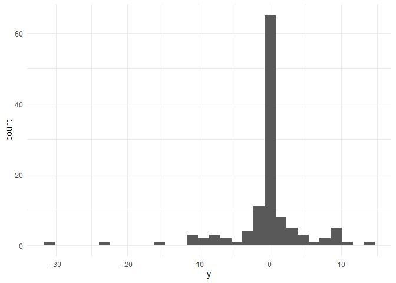

```r
ggplot(data.frame(y = whole.data$data_y), aes(x = y)) +
  geom_histogram() +
  theme_minimal()
```

- 自变量（$X, Z, W$）相关系数矩阵
  - 之前实验发现，使用 `fmrs` 包进行初始化时，如果传入的协变量之间有强相关性，则模型返回结果为空，故在此先观察分析自变量之间的相关性。

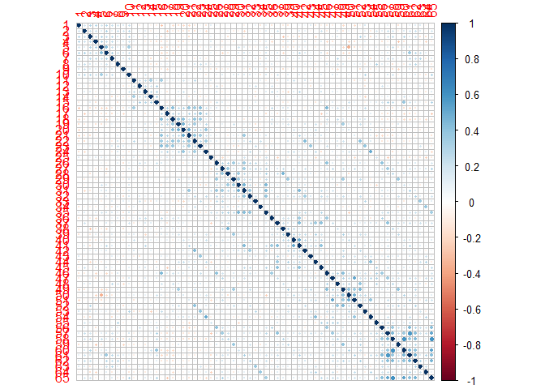

```r
# corrplot(cor(whole.data$X))
# corrplot(cor(whole.data$Z))
# corrplot(cor(whole.data$W))
corrplot(cor(whole.data$X_all))
```

# Model

## Initialization

### flexmix

- 给的组别数比较大时，`flexmix` 包不一定什么时候出现 na，在没有出现空值的时候也会 no convergence
- 每次运行结果不稳定
- 给的组别数比较合适时，会收敛
- 只能对主效应进行拟合，加入交互项后总是得到 NaN loglikelihood，原因不详

```r
library("flexmix")
K_up <- 2
# 无交互项模型
fm <- flexmix(whole.data$data_y ~ whole.data$X_main, k = K_up,
               control = list(iter.max = 100, verbose = 3))
```

```
## Classification: weighted
##    3 Log-likelihood :    -338.5979
##    6 Log-likelihood :    -328.5446
##    9 Log-likelihood :    -323.7212
##   12 Log-likelihood :    -322.1268
##   15 Log-likelihood :    -320.7801
##   18 Log-likelihood :    -317.5175
##   21 Log-likelihood :    -314.8292
##   24 Log-likelihood :    -311.6452
##   27 Log-likelihood :    -309.5676
##   30 Log-likelihood :    -308.8955
##   33 Log-likelihood :    -306.9317
##   36 Log-likelihood :    -303.5984
##   39 Log-likelihood :    -301.6205
##   42 Log-likelihood :    -298.0996
```

[output cut: 18 more lines]

```r
fm
```

```
##
## Call:
## flexmix(formula = whole.data$data_y ~ whole.data$X_main, k = K_up,
##     control = list(iter.max = 100, verbose = 3))
##
## Cluster sizes:
##  1  2
## 98 22
##
## convergence after 96 iterations
```

```r
summary(fm)
```

```
##
## Call:
## flexmix(formula = whole.data$data_y ~ whole.data$X_main, k = K_up,
##     control = list(iter.max = 100, verbose = 3))
##
##        prior size post>0 ratio
## Comp.1 0.825   98    113 0.867
## Comp.2 0.175   22     25 0.880
##
## 'log Lik.' -273.0071 (df=35)
## AIC: 616.0142   BIC: 713.5764
```

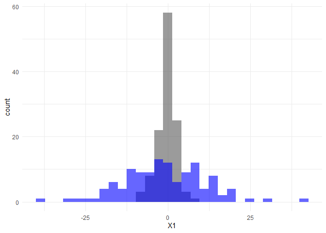

```r
# 系数分布
coef_matrix <- matrix(c(fm@components$Comp.1[[1]]@parameters$coef,
                      fm@components$Comp.2[[1]]@parameters$coef), ncol = 2)
yhat <- cbind(1, whole.data$X_main) %*% coef_matrix
yhat_df <- data.frame(yhat)
library(ggplot2)
ggplot(yhat_df) +
  geom_histogram(aes(x = X1), alpha = 0.6) +
  geom_histogram(aes(x = X2), alpha = 0.6, fill = "blue") +
  theme_minimal()
```

### RobMixReg

```r
library(RobMixReg)
# res = MLM(ml.method = 'fmr',x = whole.data$X_all,y=whole.data$data_y, nc = K_up)
# save(file = "robmixreg2.RData", res)
load("robmixreg2.RData")
```

```r
res$coff
```

```
##                    1          2
## Intercept -0.7138683 -0.1047856
## coff.x    -0.3829783  0.0000000
## sd         0.1770275  0.4274707
## mx         0.6333333  0.3666667
```

```r
table(res$cluMem)
```

```
##
##  1  2
## 76 44
```

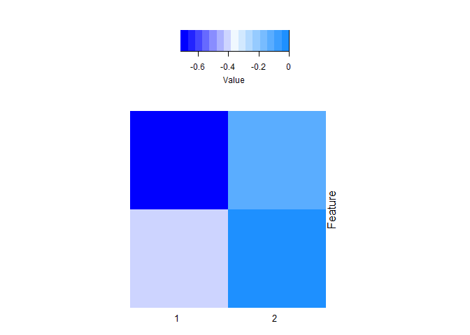

```r
compPlot(type='block', res=res)
```

```r
res$BIC
```

```
## [1] 662.7774
```

```r
# hist(res$res$posterior[[1]])
```

```r
# 得到不同类别的参数
res$res$lmList
```

```
## [[1]]
##
## Call:
## lm(formula = fml, data = tempData, weights = Wt)
##
## Coefficients:
## (Intercept)           x1           x2           x3           x4           x5
##   -0.713868    -0.382978    -0.992264    -0.163374     0.076147     1.938608
##          x6           x7           x8           x9          x10          x11
##    3.341882    -1.898229     0.079996    -0.071161     0.689896     1.768135
##         x12          x13          x14          x15          x16          x17
##   -3.363818     4.901104    -2.607584     5.345545     1.894157     3.273769
##         x18          x19          x20          x21          x22          x23
##   -0.600474     2.270703     1.479546     0.338774    -2.836080    -1.855218
##         x24          x25          x26          x27          x28          x29
##    0.151386    -4.471642     0.530869     0.602808    -0.900858    -1.900766
##         x30          x31          x32          x33          x34          x35
##    3.286881     1.111373     0.578698     2.707627    -1.547443    -2.478253
##         x36          x37          x38          x39          x40          x41
##   -0.849530    -1.160407     1.312413     0.794000     1.300127    -0.348222
##         x42          x43          x44          x45          x46          x47
##    0.003666     2.186751     0.067116     0.925914    -2.407956    -2.448299
##         x48          x49          x50          x51          x52          x53
##    1.076000    -0.678114    -3.160725     0.330740     3.841079     1.212789
##         x54          x55          x56          x57          x58          x59
##   -0.887930     3.296640     1.516742     0.412856    -3.811897     0.393137
##         x60          x61          x62          x63          x64          x65
##    0.283108    -3.928776     1.114428    -3.274776     0.928505     1.502007
##
##
## [[2]]
##
## Call:
## lm(formula = fml, data = tempData, weights = Wt)
##
## Coefficients:
## (Intercept)
##     -0.1048
```

### fmrs

> 截距项处理，系数相同问题
- 解决问题：各类别系数相同
  - 参数初始化重要，不能 `rep`，考虑随机生成
  - Hierarchical 文章初始值设置为 (1,1,…,1,-1,-1,…,-1)，仿照此会将只能分为两组

```r
int_rm <- TRUE
K_up <- 4
as <- matrix(1, nrow = p+q+pq+1, ncol = K_up)
if(int_rm){ as[1,] <- 0 }

# 初始化参数
# coef_rough_init <- rep(1, K_up * (p+q+pq+1))
# coef_rough_init <- c(rep(1, K_up * (p+q+pq+1) %/% 2),
#                      rep(0.5, K_up * (p+q+pq+1) - K_up * (p+q+pq+1) %/% 2))
coef_rough_init <- rnorm(K_up * (p+q+pq+1))
res.mle <- fmrs.mle(
  y = whole.data$data_y,
  x = whole.data$X_all,
  delta = rep(0, length(whole.data$data_y)),
  nComp = K_up,
  disFamily = "norm",
  initCoeff = coef_rough_init,
  initDispersion = rep(1, K_up),
  initmixProp = rep(1 / K_up, K_up),
  nIterNR = 200,
  activeset = as
)
# summary(res.mle)
coefficients(res.mle)
```

```
##                Comp.1      Comp.2      Comp.3      Comp.4
## Intercept  0.00000000  0.00000000  0.00000000  0.00000000
## X.1       -0.22179198 -0.34532844  1.18110039  3.58292006
## X.2       -1.61262829 -0.95271628 -1.08485640  0.57470022
## X.3       -1.80358195 -4.98040489 -4.37657640 -2.11617101
## X.4       -0.91353394 -2.57305500 -1.35955398 -7.59423733
## X.5        0.27949980  1.85143739 -2.28795524  0.38814287
## X.6        3.64115795  1.09322356  2.97215308  4.15265577
## X.7        1.03146222 -1.62780729  1.64726366 -4.08844544
## X.8        0.55223844 -0.84576929  0.36136952 -3.38651672
## X.9        0.04952513 -1.16259921  1.56934726  0.93999168
## X.10       0.32625806  6.72519502  1.43217818  5.18306280
## X.11       1.69509399  6.63332278  2.95880107  4.04879343
## X.12      -2.39738709 -1.47696031 -0.46105044 -2.75991951
## X.13       2.25163620  1.06305214  1.05013363 -4.85211643
## X.14      -0.94701452 -4.29546438 -0.08591013 -0.41430033
## X.15       3.38733329  3.01347634 -0.13725811  0.16190634
## X.16      -2.05772139 -3.67626083  2.28485857  1.06958820
## X.17       0.69423607  4.41306715  1.80417578 -3.53595416
## X.18      -2.36945039 -2.69925074 -0.13154333 -2.69811951
## X.19       1.47910806  1.20674019  6.28138246  4.06932031
## X.20       0.35296213  0.44914188 -4.95718594  0.51413321
## X.21       3.10720756 -1.91746449  0.41326866 -0.37059583
## X.22       2.64110028 -2.59868822  1.67986236  1.66006267
## X.23      -1.54624643  0.50027311 -2.39922040  0.68387193
## X.24      -4.94315606 -3.70006787 -1.57886224 -6.44609987
## X.25      -1.19657169  1.27203776 -3.70878382 -1.00464896
## X.26       4.25312742  0.19517818  1.09881423  0.70837376
## X.27       2.06088261 -1.45822339  2.17241659 -4.15329561
## X.28      -2.13028865 -3.78742150  1.50266533  0.03935096
## X.29      -5.51606799 -0.72700408  0.32766865 -5.33534898
## X.30      -0.32580671 -1.92437064  0.33703482 -0.49220150
## X.31       1.70760921  4.27744647  1.33003695  6.04867060
## X.32       2.28125362 -1.80509638 -2.33631800 -3.19855903
## X.33       2.79906942  2.08702448 -2.05873934 -2.16823793
## X.34      -0.94583560  2.21357886 -2.15018363  6.48130294
## X.35      -1.04419446  4.93257172  1.38025153 -0.31704770
## X.36       1.65068621  1.71174864 -0.20232227  5.53060209
## X.37       4.43463313  4.90265799 -3.33957077  2.97018517
## X.38      -0.41172808  2.68031552 -5.97617560 -6.37965790
```

[output cut: 12 more lines]

```
## X.51      -2.60138029  3.53889263 -2.35281247  5.80736099
## X.52       0.18857646  2.21361261  3.01842078  4.03762490
## X.53       1.41283102  0.04517742  0.62259598 -1.19457396
## X.54       3.97056421  3.31084563  2.86904283  4.89646886
## X.55       3.16755307  2.54251464  2.63938953 10.07738366
## X.56       0.20023870  1.01481160 -1.13002013  4.66001553
## X.57      -1.97359558 -3.20115632 -1.82288987  1.62352785
## X.58       1.30799345 -1.73957460 -2.71150750 -2.68231848
## X.59      -2.27888843  1.51664297 -1.73397540 -5.11740681
## X.60       2.71351171  6.88450669  2.85800435  1.93386397
## X.61      -1.95191380 -5.67579477 -1.44298473 -5.93884023
## X.62      -0.07627648  4.58466874  1.47926136  6.05625939
## X.63      -3.37679220 -2.45841001  0.25356867  2.92651678
## X.64      -2.29475479  0.18076574 -2.58815087 -6.90291654
## X.65      -2.19328054 -6.97008320  1.68199386 -5.20408285
```

- `fmrs.tunsel`: The maximizer of penalized Log-Likelihood depends on selecting a set of good tuning parameters which is a rather thorny issue. We choose a value in an equally spaced set of values in $(0, \lambda_{max})$ for a pre-specified λmax that maximize the component-wise BIC

$\hat{\lambda}_{k}=\operatorname{argmax}_{\lambda_{k}} B I C_{k}\left(\lambda_{k}\right)=\operatorname{argmax}_{\lambda_{k}}\left\{\ell_{k, n}^{c}\left(\hat{\Psi}_{\lambda_{k}, k}\right)-\left|d_{\lambda_{k}, k}\right| \log (n)\right\},$

where $d_{\lambda_{k}, k}=\left\{j: \hat{\beta}_{\lambda_{k}, k j} \neq 0, j=1, \ldots, d\right\}$ is the active set excluding the intercept and $\left|d_{\lambda_{k}, k}\right|$ is its size. This approach is much faster than using an nComp by nComp grid to select the set $\boldsymbol{\lambda}$ to maximize the penallized Log-Likelihood.

```r
res.lam <- fmrs.tunsel(y = whole.data$data_y,
                       x = whole.data$X_all,
                       delta = rep(0, length(whole.data$data_y)),
                       nComp = K_up,
                       disFamily = "norm",
                       initCoeff = c(coefficients(res.mle)),
                       initDispersion = dispersion(res.mle),
                       initmixProp = mixProp(res.mle),
                       penFamily = "mcp",
                       nIterNR = 200,
                       activeset = as
)
res.lam@lambPen
```

```
##      Comp.1 Comp.2 Comp.3 Comp.4
## [1,]   0.05    0.1   0.79    0.8
```

- `fmrs.varsel`: Provides variable selection and penalized MLE for Finite Mixture of Regression (FMR) Models. The penalized likelihood of a finite mixture of the models is written as

$$\tilde{\ell}_{n}(\boldsymbol{\Psi})=\ell_{n}(\boldsymbol{\Psi})-\mathbf{p}_{\boldsymbol{\lambda}_{n}}(\boldsymbol{\Psi})$$

where

$$\mathbf{p}_{\boldsymbol{\lambda}_{n}}(\boldsymbol{\Psi})=\sum_{k=1}^{K} \pi_{k}^{\alpha}\left\{\sum_{j=1}^{d} p_{\lambda_{n, k}}\left(\beta_{k j}\right)\right\}$$

```r
res.var <- fmrs.varsel(y = whole.data$data_y,
                       x = whole.data$X_all,
                       delta = rep(0, length(whole.data$data_y)),
                       nComp = ncomp(res.mle),
                       disFamily = "norm",
                       initCoeff = c(coefficients(res.mle)),
                       initDispersion = dispersion(res.mle),
                       initmixProp = mixProp(res.mle),
                       penFamily = "mcp",
                       lambPen = slot(res.lam, "lambPen"),
                       nIterNR = 200
)
res.var@dispersion
```

```
##           Comp.1     Comp.2   Comp.3   Comp.4
## [1,] 0.003316651 0.01783395 1.830833 1.848243
```

```r
res.var@mixProp
```

```
##         Comp.1    Comp.2     Comp.3    Comp.4
## [1,] 0.4831559 0.3143113 0.07031082 0.1322219
```

```r
fmr_res <- c()
fmr_weight_ci <- apply(res.var@weights,1,which.max)
fmr_res_ci <- apply(abs(res.var@residuals),1,which.min)
for (i in 1:n) {
  fmr_res[i] <- res.var@residuals[i, fmr_res_ci[i]]
}
fmr_var <- sqrt(sum(fmr_res^2))
fmr_bic <- res.var@BIC

fmr_coe <- res.var@coefficients
if(int_rm){ fmr_coe <- res.var@coefficients[-1,]  }

# 针对类别，每个系数拉长作为列向量
coef_init <- as.vector(fmr_coe)
```

```r
table(ci_sim, fmr_weight_ci)
```

```
##       fmr_weight_ci
## ci_sim  1  2  3  4
##      1 11 12  1  6
##      2 14  9  1  6
##      3 17  7  1  5
##      4 16 10  1  3
```

```r
table(ci_sim, fmr_res_ci)
```

```
##       fmr_res_ci
## ci_sim  1  2  3  4
##      1 13 13  2  2
##      2 14 12  1  3
##      3 17  7  1  5
##      4 17 10  1  2
```

```r
prop.table(table(fmr_weight_ci))
```

```
## fmr_weight_ci
##          1          2          3          4
## 0.48333333 0.31666667 0.03333333 0.16666667
```

```r
prop.table(table(fmr_res_ci))
```

```
## fmr_res_ci
##          1          2          3          4
## 0.50833333 0.35000000 0.04166667 0.10000000
```

```r
iter_max <- 50

idx_X <- c(1:(p))
idx_Z <- c((p+1):((p+q)))
idx_W <- c(((p+q)+1):((p+q+pq)))
idx_X_full <- sort(rep((0:(K-1))*(p+q+pq), p)) + idx_X
idx_Z_full <- sort(rep((0:(K-1))*(p+q+pq), q)) + idx_Z
idx_W_full <- sort(rep((0:(K-1))*(p+q+pq), pq)) + idx_W
coef_init_beta <- coef_init[idx_X_full]
coef_init_alpha <- coef_init[idx_Z_full]
coef_init_gamma <- coef_init[idx_W_full]

X <- whole.data$X_all
X_full <- whole.data$data_X_all
y <- whole.data$data_y

####################### Initialize coef ######################
# group
u_init <- H_1 %*% coef_init_beta
v_init <- H_2 %*% coef_init_alpha
w_init <- H_3 %*% coef_init_gamma
xi_init <- Matrix(0, ncol=1, nrow=p*K*(K-1)/2, sparse=T)
zeta_init <- Matrix(0, ncol=1, nrow=q*K*(K-1)/2, sparse=T)
eta_init <- Matrix(0, ncol=1, nrow=pq*K*(K-1)/2, sparse=T)

# iteration
iter <- 1
coef_beta_est_list <- vector(mode="list", length=iter_max)
coef_alpha_est_list <- vector(mode="list", length=iter_max)
coef_gamma_est_list <- vector(mode="list", length=iter_max)
coef_beta_est_list[[iter]] <- coef_init_beta
coef_alpha_est_list[[iter]] <- coef_init_alpha
coef_gamma_est_list[[iter]] <- coef_init_gamma

u_est_list <- vector(mode="list", length=iter_max); u_est_list[[iter]] <- u_init
v_est_list <- vector(mode="list", length=iter_max); v_est_list[[iter]] <- v_init
w_est_list <- vector(mode="list", length=iter_max); w_est_list[[iter]] <- w_init

xi_est_list <- vector(mode="list", length=iter_max)
zeta_est_list <- vector(mode="list", length=iter_max)
eta_est_list <- vector(mode="list", length=iter_max)
xi_est_list[[iter]] <- xi_init
zeta_est_list[[iter]] <- zeta_init
eta_est_list[[iter]] <- eta_init
```